# Homework 3 - Divij Sanjanwala

## Question 1.3:

For each model, create maps of the random effects (both iid and rw2d), the predicted counts per cell along with the lower and upper limits of the 95% credible interval of predicted counts. Interpret the output.

```r
grid$respa.weak <- res.weak$summary.random$id[grid$id, "mean"]
grid$respa.non.inform <- res.non.inform$summary.random$id[grid$id, "mean"]

grid$reiid.weak <- res.weak$summary.random$id2[, "mean"]
grid$reiid.non.inform <- res.non.inform$summary.random$id2[, "mean"]
```

### Graphing Model 1 Random Effects and Spatial Effects - Weakly Informative Prior

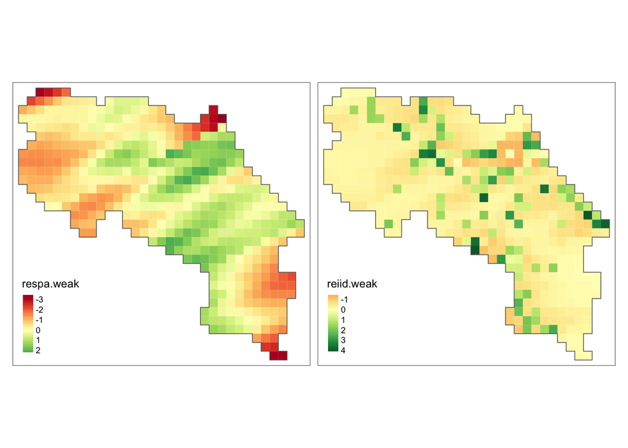

```r
tm_shape(grid) +
  tm_polygons(col = c("respa.weak", "reiid.weak"), style = "cont", border.col = "transparent")  +
  tm_shape(gridborder) + tm_borders() +
  tm_facets(ncol = 2) + tm_legend(legend.position = c("left", "bottom"))
```

### Graphing Model 2 Random and Spatial Effects - Non Informative Prior

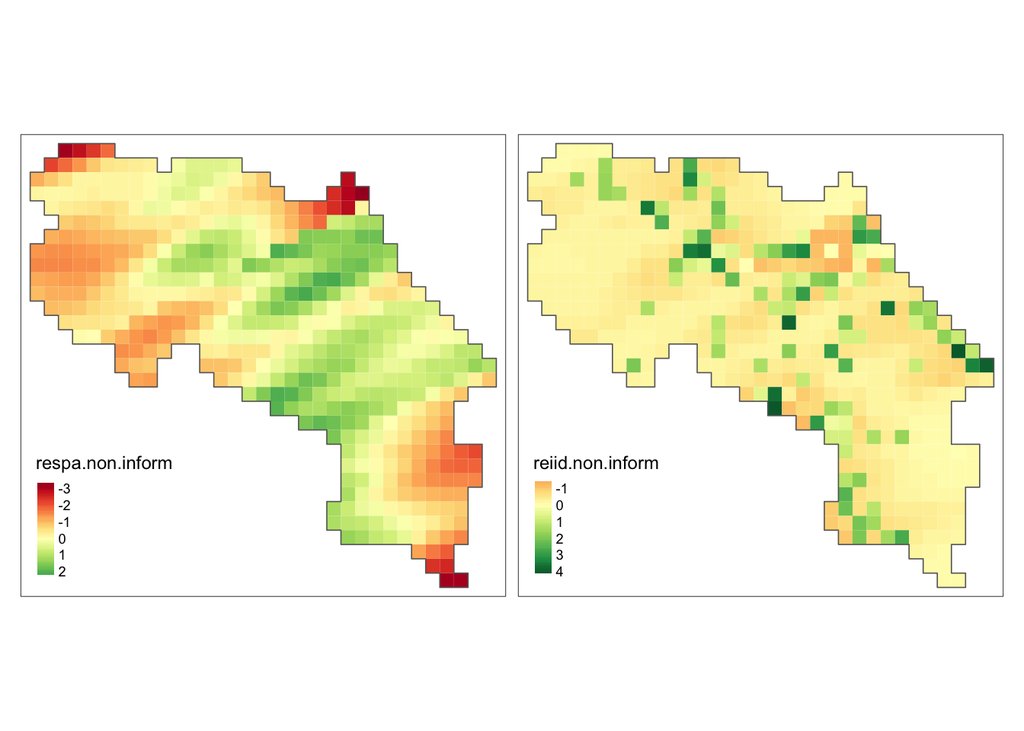

```r
tm_shape(grid) +
  tm_polygons(col = c("respa.non.inform", "reiid.non.inform"), style = "cont", border.col = "transparent")  +
  tm_shape(gridborder) + tm_borders() +
  tm_facets(ncol = 2) + tm_legend(legend.position = c("left", "bottom"))
```

```r
cellarea <- resolution*resolution

grid$NE.weak <- res.weak$summary.fitted.values[, "mean"] * cellarea
grid$LL.weak <- res.weak$summary.fitted.values[, "0.025quant"] * cellarea
grid$UL.weak <- res.weak$summary.fitted.values[, "0.975quant"] * cellarea

grid$NE.non.inform <- res.non.inform$summary.fitted.values[, "mean"] * cellarea
grid$LL.non.inform <- res.non.inform$summary.fitted.values[, "0.025quant"] * cellarea
grid$UL.non.inform <- res.non.inform$summary.fitted.values[, "0.975quant"] * cellarea
```

### Graphing Model 1 Expected and 95% Intervals - Weakly Informative Prior

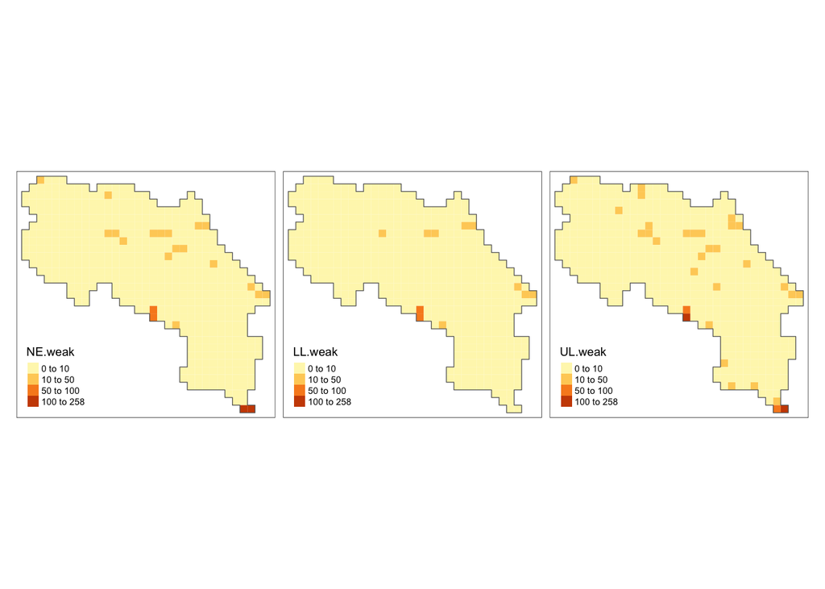

```r
tm_shape(grid) +
  tm_polygons(col = c("NE.weak", "LL.weak", "UL.weak"),
              style = 'fixed', border.col = "transparent",
              breaks = c(0, 10, 50, 100, ceiling(max(grid$UL.weak)))) +
  tm_shape(gridborder) + tm_borders() +
  tm_facets(ncol = 3) + tm_legend(legend.position = c("left", "bottom"))
```

### Graphing Model 2 Expected and 95% Intervals - Non Informative Prior

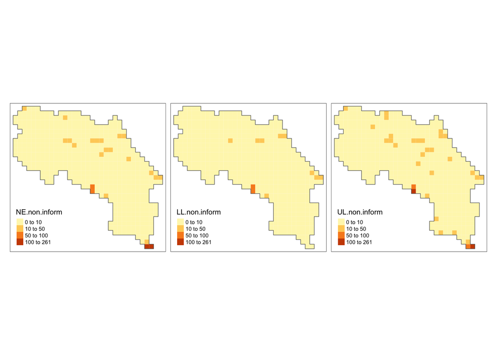

```r
tm_shape(grid) +
  tm_polygons(col = c("NE.non.inform", "LL.non.inform", "UL.non.inform"),
              style = 'fixed', border.col = "transparent",
              breaks = c(0, 10, 50, 100, ceiling(max(grid$UL.non.inform)))) +
  tm_shape(gridborder) + tm_borders() +
  tm_facets(ncol = 3) + tm_legend(legend.position = c("left", "bottom"))
```

### Interpret the output:

Given the comment in the previous question, it appears quite obvious that the Upper Limit for the model with non informative priors will be higher than that of the “weakly” informative priors. Although the regions are similarly predicted, with the concentration of higher and lower values being the same across both the models, leading to very similar distribution of estimates. Besides this, the models are similar in prediction. The lower and upper and limits have a similar concentration for higher and lower values.

# Question 2:

## Question 2.1:

For the lung cancer in Pennsylvania data set, fit the following five models in INLA using the default priors: • Complete pooling and smoking covariate (no random effects) • Hierarchical random effect (iid) - (intercept only) • Hierarchical random effect (iid) + smoking covariate • Spatial + iid random effect • Spatial + iid random effect + smoking covariate

```r
data(pennLC)
population <- pennLC$data$population
cases <- pennLC$data$cases
n.strata <- 16
E <- expected(population, cases, n.strata)
d <- aggregate(x = pennLC$data$cases, by = list(county = pennLC$data$county), FUN = sum)
population_count <- aggregate(x = pennLC$data$population, by = list(county = pennLC$data$county), FUN = sum)



# from spatial polygon to simple feature
pennLC.sf <- st_as_sf(pennLC$spatial.polygon)
pennLC.sf$county <- d$county
pennLC.sf$counts <- d$x
pennLC.sf$E <- E[match(pennLC.sf$county, unique(pennLC$data$county))]
pennLC.sf <- merge(pennLC.sf, pennLC$smoking, by.x = "county", by.y = "county")
pennLC.sf <- pennLC.sf%>%
  mutate(SIR = counts/E)
pennLC.sf$population <- population_count$x
```

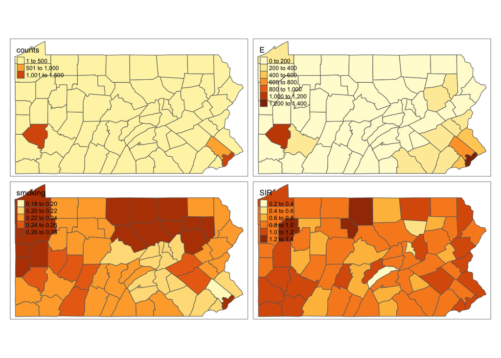

```r
tm_shape(pennLC.sf) + tm_polygons(c("counts", "E", "smoking", "SIR")) +
  tm_facets(ncol = 2)
```

```r
## Values of E_i and neighborhood structure
E.penn <- pennLC.sf$E
pop.penn <- pennLC.sf$population
neighbor.penn <- poly2nb(pennLC.sf)

nb2INLA("npenn.adj", neighbor.penn)
g <- inla.read.graph(filename = "npenn.adj")

pennLC.sf$re_u <- 1:nrow(pennLC.sf)
pennLC.sf$re_v <- 1:nrow(pennLC.sf)

# Complete pooling and smoking covariate
formula1 <- counts ~ smoking

res1 <- inla(formula1, family = "poisson", data = pennLC.sf, E = E.penn,
            control.predictor = list(compute = TRUE),
            control.fixed = list(mean.intercept = 0,
                                 prec.intercept = 1,
                                 mean = 0,
                                 prec = 1),
            control.compute=list(cpo = TRUE, dic = TRUE, waic = TRUE))

# Hierarchical random effect (iid) - (intercept only)
formula2 <- counts ~ f(re_v, model = "iid",
                       hyper = list(prec = list(prior = "loggamma",
                                                param = c(0.1,  0.1))))

res2 <- inla(formula2, family = "poisson", data = pennLC.sf, E = E.penn,
            control.predictor = list(compute = TRUE),
            control.fixed = list(mean.intercept = 0,
                                 prec.intercept = 1,
                                 mean = 0,
                                 prec = 1),
            control.compute=list(cpo = TRUE, dic = TRUE, waic = TRUE))

# Hierarchical random effect (iid) + smoking covariate
formula3 <- counts ~ smoking +
  f(re_v, model = "iid",
    hyper = list(prec = list(prior = "loggamma",param = c(0.1,  0.1))))

res3 <- inla(formula3, family = "poisson", data = pennLC.sf, E = E.penn,
            control.predictor = list(compute = TRUE),
            control.fixed = list(mean.intercept = 0,
                                 prec.intercept = 1,
                                 mean = 0,
                                 prec = 1),
            control.compute=list(cpo = TRUE, dic = TRUE, waic = TRUE))

# Spatial + iid random effect
formula4 <- counts ~ f(re_u, model = "besag", graph = g,
                       hyper = list(prec = list(prior = "loggamma",
                                                param = c(0.1,  0.1)))) +
  f(re_v, model = "iid",
    hyper = list(prec = list(prior = "loggamma",param = c(0.1,  0.1))))

res4 <- inla(formula4, family = "poisson", data = pennLC.sf, E = E.penn,
            control.predictor = list(compute = TRUE),
            control.fixed = list(mean.intercept = 0,
                                 prec.intercept = 1,
                                 mean = 0,
                                 prec = 1),
            control.compute=list(cpo = TRUE, dic = TRUE, waic = TRUE))

# Spatial + iid random effect + smoking covariate
formula5 <- counts ~ smoking +
  f(re_u, model = "besag", graph = g,
    hyper = list(prec = list(prior = "loggamma",param = c(0.1,  0.1)))) +
  f(re_v, model = "iid",
    hyper = list(prec = list(prior = "loggamma",param = c(0.1,  0.1))))

res5 <- inla(formula5, family = "poisson", data = pennLC.sf, E = E.penn,
            control.predictor = list(compute = TRUE),
            control.fixed = list(mean.intercept = 0,
                                 prec.intercept = 1,
                                 mean = 0,
                                 prec = 1),
            control.compute=list(cpo = TRUE, dic = TRUE, waic = TRUE))
```

Computing the Prevalence Rates using the count outcome variable.

```r
pennLC.sf$model1.predicted_prevalence <- (res1$summary.fitted.values[,"mean"]*E.penn)
pennLC.sf$model1.sd.predicted_prevalence <- (res1$summary.fitted.values[,"sd"]*E.penn)
pennLC.sf$model2.mean.predicted_prevalence <- (res2$summary.fitted.values[,"mean"]*E.penn)
pennLC.sf$model2.sd.predicted_prevalence <- (res2$summary.fitted.values[,"sd"]*E.penn)
pennLC.sf$model3.mean.predicted_prevalence <- (res3$summary.fitted.values[,"mean"]*E.penn)
pennLC.sf$model3.sd.predicted_prevalence <- (res3$summary.fitted.values[,"sd"]*E.penn)
pennLC.sf$model4.mean.predicted_prevalence <- (res4$summary.fitted.values[,"mean"]*E.penn)
pennLC.sf$model4.sd.predicted_prevalence <- (res4$summary.fitted.values[,"sd"]*E.penn)
pennLC.sf$model5.mean.predicted_prevalence <- (res5$summary.fitted.values[,"mean"]*E.penn)
pennLC.sf$model5.sd.predicted_prevalence <- (res5$summary.fitted.values[,"sd"]*E.penn)
```

```r
res1.m1.mean <- tm_shape(pennLC.sf) +
  tm_polygons("model1.predicted_prevalence") +
  tm_layout(main.title = "Predicted Prevalence Rate - Model 1")

res1.m1.sd <- tm_shape(pennLC.sf) +
  tm_polygons("model1.sd.predicted_prevalence") +
  tm_layout(main.title = "Standard Deviation of Predicted Prevalence Rate - Model 1")

res2.m1.mean <- tm_shape(pennLC.sf) +
  tm_polygons("model2.mean.predicted_prevalence") +
  tm_layout(main.title = "Predicted Prevalence Rate - Model 2")

res2.m1.sd <- tm_shape(pennLC.sf) +
  tm_polygons("model2.sd.predicted_prevalence") +
  tm_layout(main.title = "Standard Deviation of Predicted Prevalence Rate - Model 2")

res3.m1.mean <- tm_shape(pennLC.sf) +
  tm_polygons("model3.mean.predicted_prevalence") +
  tm_layout(main.title = "Predicted Prevalence Rate - Model 3")

res3.m1.sd <- tm_shape(pennLC.sf) +
  tm_polygons("model3.sd.predicted_prevalence") +
  tm_layout(main.title = "Standard Deviation of Predicted Prevalence Rate - Model 3")

res4.m1.mean <- tm_shape(pennLC.sf) +
  tm_polygons("model4.mean.predicted_prevalence") +
  tm_layout(main.title = "Predicted Prevalence Rate - Model 4")

res4.m1.sd <- tm_shape(pennLC.sf) +
  tm_polygons("model4.sd.predicted_prevalence") +
  tm_layout(main.title = "Standard Deviation of Predicted Prevalence Rate - Model 4")

res5.m1.mean <- tm_shape(pennLC.sf) +
  tm_polygons("model5.mean.predicted_prevalence") +
  tm_layout(main.title = "Predicted Prevalence Rate - Model 5")

res5.m1.sd <- tm_shape(pennLC.sf) +
  tm_polygons("model5.sd.predicted_prevalence") +
  tm_layout(main.title = "Standard Deviation of Predicted Prevalence Rate - Model 5")
```

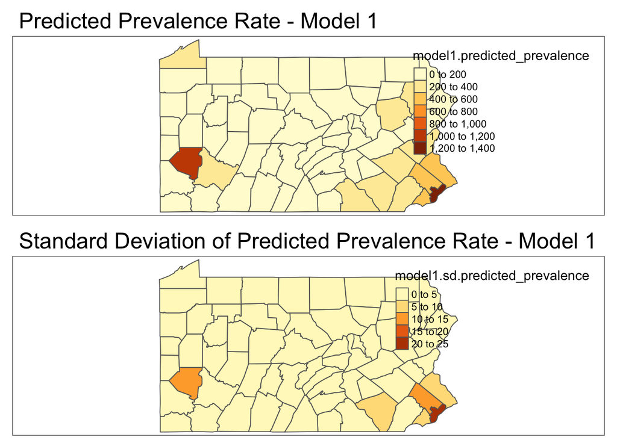

```r
tmap_arrange(res1.m1.mean, res1.m1.sd, ncol=1)
```

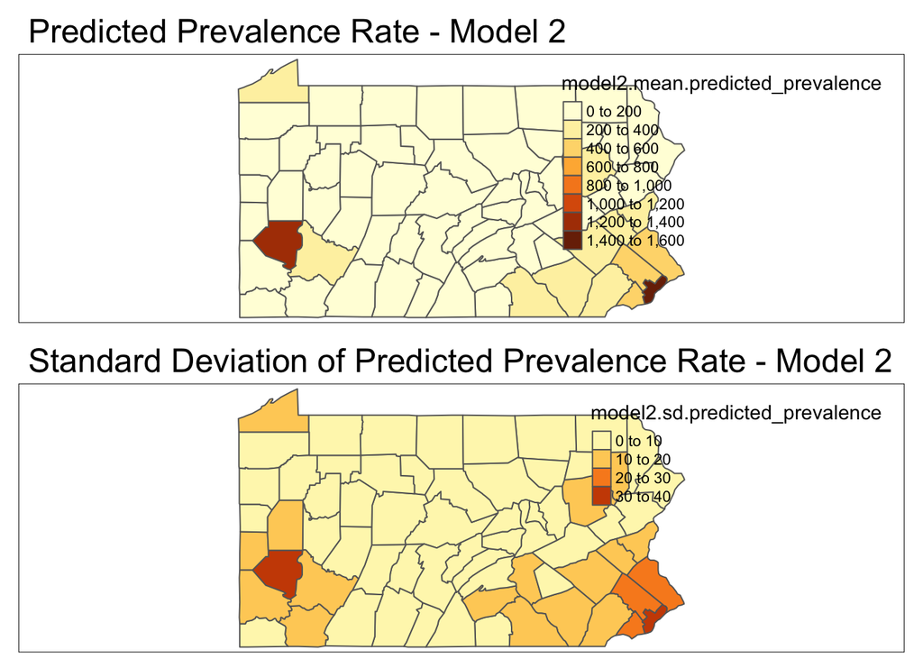

```r
tmap_arrange(res2.m1.mean, res2.m1.sd, ncol=1)
```

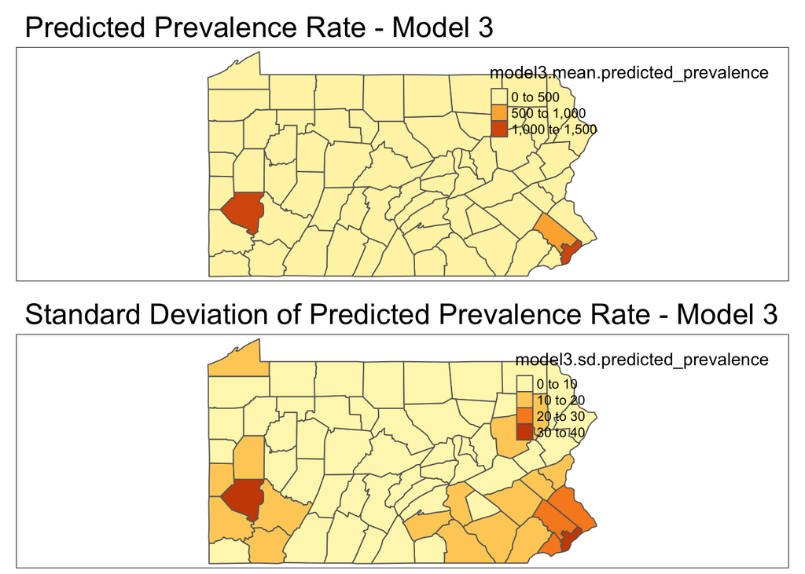

```r
tmap_arrange(res3.m1.mean, res3.m1.sd, ncol=1)
```

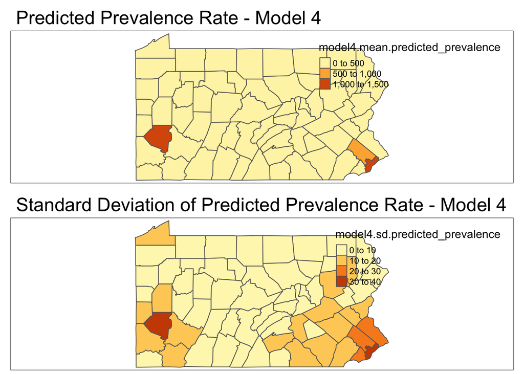

```r
tmap_arrange(res4.m1.mean, res4.m1.sd, ncol=1)
```

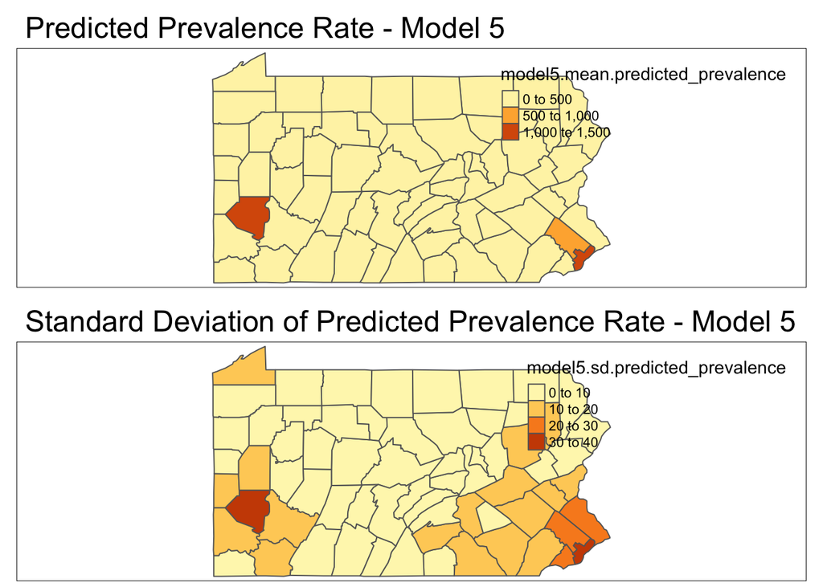

```r
tmap_mode("plot")
tmap_arrange(res5.m1.mean, res5.m1.sd, ncol=1)
```

```r
cpo <- list(sum(log(res1$cpo$cpo)), sum(log(res2$cpo$cpo)), sum(log(res3$cpo$cpo)), sum(log(res4$cpo$cpo)), sum(log(res5$cpo$cpo)))
pit <- list(sum(log(res1$cpo$pit)), sum(log(res2$cpo$pit)), sum(log(res3$cpo$pit)), sum(log(res4$cpo$pit)), sum(log(res5$cpo$pit)))
cpo.pic.df <- data.frame("Model 1" = c(cpo[[1]], pit[[1]]), "Model 2" = c(cpo[[2]], pit[[2]]), "Model 3" = c(cpo[[3]], pit[[3]]), "Model 4" = c(cpo[[4]], pit[[4]]), "Model 5" = c(cpo[[5]], pit[[5]]))
rownames(cpo.pic.df) <- c("CPO", "PIT")
cpo.pic.df
```

```
##       Model.1    Model.2    Model.3   Model.4    Model.5
## CPO -287.6452 -268.74220 -268.34944 -273.8407 -273.92134
## PIT -111.3529  -70.41897  -70.28127  -72.2135  -72.25417
```